# Plant Root Simulator (PRS) Analysis from 2025 Greenhouse Study

Renee Davis

2026-02-09

# 1 Methods

## 1.1 Sample Collection

A pair (anion and cation) of Plant Root Simulator (PRS) probes were buried in pots at the end of week 5 and retrieved at the end of week 7 (14 day burial period). Upon removal, they were rinsed with DI water, aggregated into groups of 2 or 3 pairs (each treatment having 7 probe pairs) shipped to Western Ag for HPLC analysis. Data are received as nutrient supply rate (ug/10cm^2/14 days). There are 16 total anions and cations reported. For the purposes of this study, we will focus on nitrate, ammonium, and phosphate.

## 1.2 Data Structure and Statistical Analysis

Unlike the other datasets, there isn’t a distinct sample unit for each treatment. I will run the ANOVA for each Treatment Category as-is (that is to say that there are 3 analyses that represent 7 biological replicates) to keep as full of a picture as possible. There are different possible approaches however. This can be condensed into the mean of each ion for a treatment category. One can also go in the opposite direction: the sample units can be expanded and parsed out using the reported nutrient supply rate.

For an initial analysis, the impact of treatments on each ion will be evaluate via ANOVA. It can be melded with week 6 soil moisture and nutrient leachate datasets for downstream multivariate analyses.

## 1.3 Hypotheses and Expectations

1. AMF-containing treatments (T2, T3, T4, T6) will show lower plant-available phosphate (PRS) compared to non-AMF treatments due to active P depletion via mycorrhizal uptake.
2. Bacterial inoculant treatments (T1, T3, T4, T5) will exhibit higher available NO₃⁻ at the PRS probes compared to controls due to nitrogen fixation activity.
3. Strigolactone-primed treatments (T4, T5, T6) will demonstrate greater nutrient depletion zones (lower PRS values for N and P) compared to non-primed equivalents due to enhanced microbial activity and plant-microbe associations.
4. Combined bacteria+AMF treatments (T3, T4) will show the lowest available N and P at PRS probes, reflecting most efficient nutrient capture and cycling.
5. Synthetic fertilizer (T13) will exhibit highest cation concentrations (Ca, Mg, K) initially, but lowest by week 8 due to rapid early availability followed by plant uptake and leaching losses.

# 2 Results

## 2.1 Nitrate

### 2.1.1 Violin plot

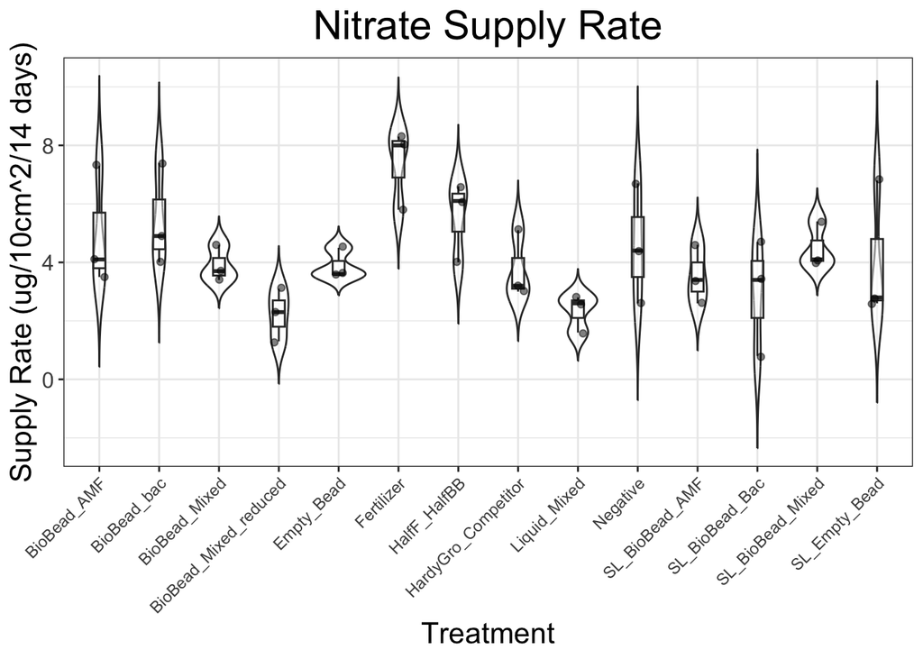

Fertilizer treatments are associated with the highest nitrate supply rate. The BioBead and liquid consortia treatments are associated with some of the lowest.

### 2.1.2 One Way ANOVA

```
##                    Df Sum Sq Mean Sq F value Pr(>F)
## Treatment_Category 13  71.78   5.521   2.605 0.0165 *
## Residuals          28  59.35   2.120
## ---
## Signif. codes:  0 '***' 0.001 '**' 0.01 '*' 0.05 '.' 0.1 ' ' 1
```

There were significant differences among treatment groups for nitrate supply rate (F stat (13,28) = 2.605, p = 0.0165).

### 2.1.3 Tukey Test

There were significant differences among the following treatment groups for nitrate supply rate: Fertilizer and Liquid_Mixed (p = 0.0128161), Fertilizer and SL_BioBead_Bac (p = 0.0455666), and Fertilizer and BioBead_Mixed_reduced (p = 0.0104057). All involve fertilizer.

### 2.1.4 Shapiro Wilk test for normality

```
##
##  Shapiro-Wilk normality test
##
## data:  anova_NO3$residuals
## W = 0.97724, p-value = 0.5571
```

The W value and high p value indicate residual normality.

### 2.1.5 Residuals distribution

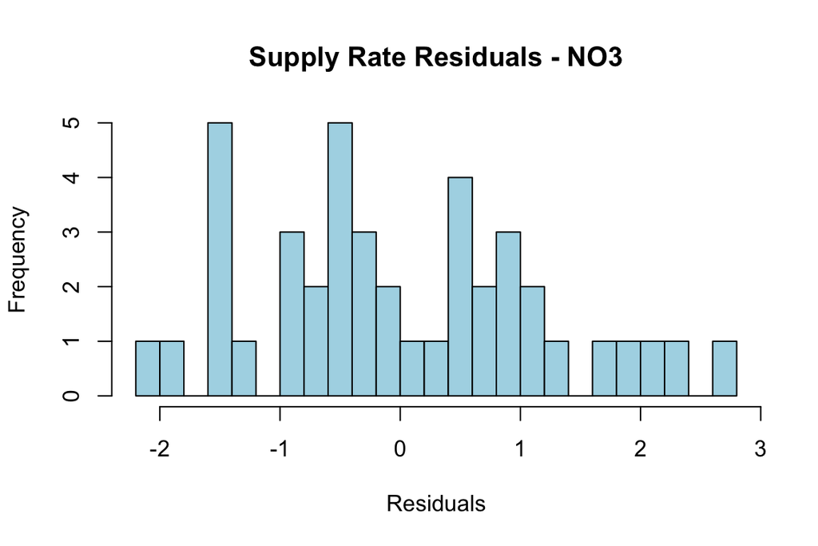

### 2.1.6 Quantile-Quantile plots

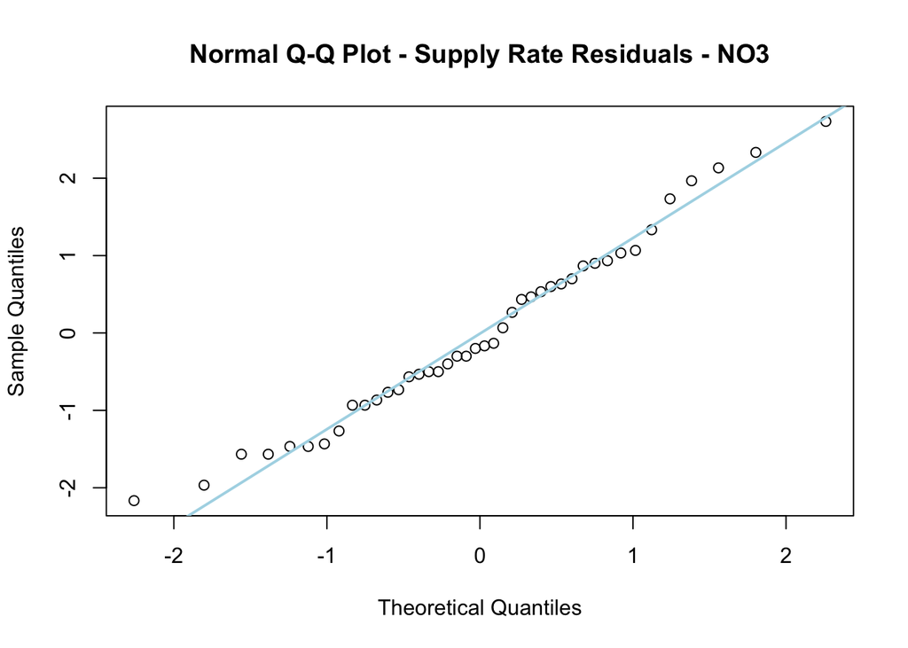

```r
qqnorm(anova_NO3$residuals, main = "Normal Q-Q Plot - Supply Rate Residuals - NO3")
qqline(anova_NO3$residuals, col = "lightblue", lwd = 2)
```

## 2.2 Ammonium

### 2.2.1 Violin plot

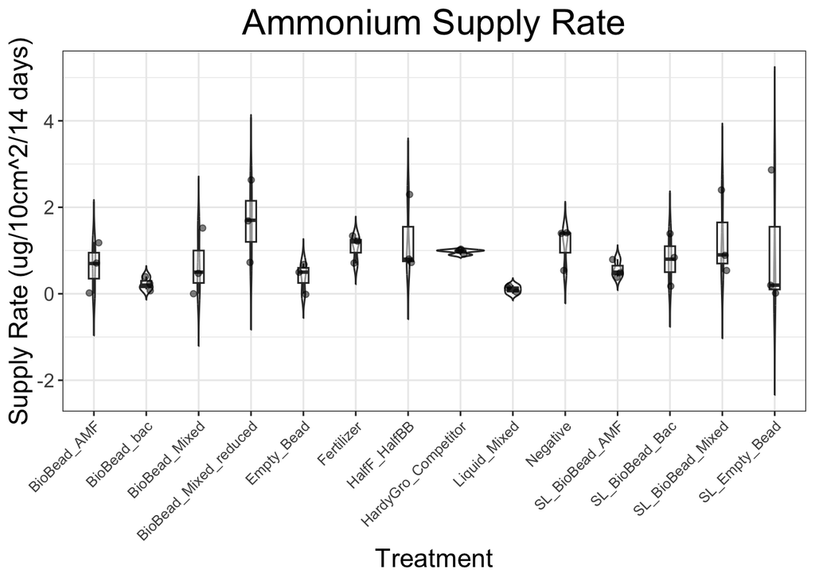

### 2.2.2 One Way ANOVA

```
##                    Df Sum Sq Mean Sq F value Pr(>F)
## Treatment_Category 13  7.435  0.5719   1.108  0.392
## Residuals          28 14.447  0.5160
```

There were not significant differences among treatment groups for ammonium supply rate (F stat (13,28) = 1.108, p = 0.392).

### 2.2.3 Tukey Test

There were no significant differences among the following treatment groups for ammonium in a post-hoc Tukey HSD test.

### 2.2.4 Shapiro Wilk test for normality

```
##
##  Shapiro-Wilk normality test
##
## data:  anova_NH4$residuals
## W = 0.9519, p-value = 0.07553
```

The W and p value indicate borderline normality with residuals.

### 2.2.5 Residuals distribution

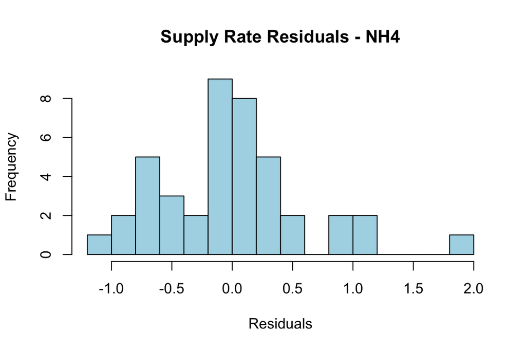

### 2.2.6 Quantile-Quantile plots

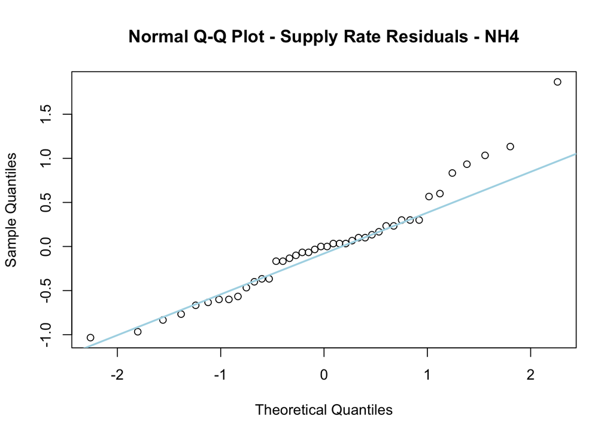

```r
qqnorm(anova_NH4$residuals, main = "Normal Q-Q Plot - Supply Rate Residuals - NH4")
qqline(anova_NH4$residuals, col = "lightblue", lwd = 2)
```

## 2.3 Phosphate

### 2.3.1 Violin plot

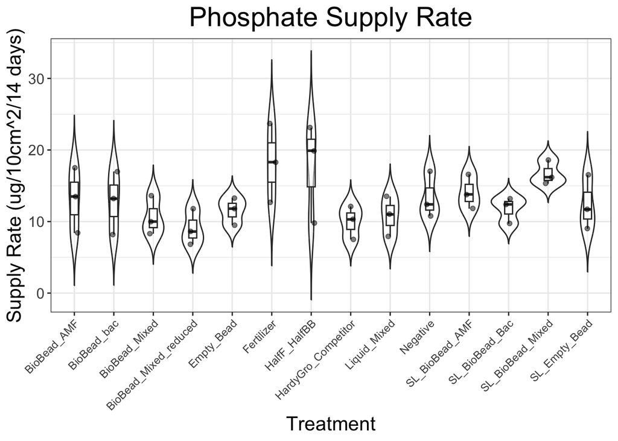

Fertilizer and 1/2 dose BioBead treatments are associated with higher phosphate supply rates (and more variation).The empty bead, HardyGro, and BioBead formuations have lower phosphate supply rates.

### 2.3.2 One Way ANOVA

```
##                    Df Sum Sq Mean Sq F value Pr(>F)
## Treatment_Category 13  308.2   23.71   1.782 0.0976 .
## Residuals          28  372.5   13.30
## ---
## Signif. codes:  0 '***' 0.001 '**' 0.01 '*' 0.05 '.' 0.1 ' ' 1
```

There were no significant differences among treatment groups for phosphate supply rate (F stat (13,28) = 1.782, p = 0.0976).

### 2.3.3 Tukey Test

There were no significant differences among the following treatment groups for phosphate supply rate in a post-hoc Tukey HSD test.

### 2.3.4 Shapiro Wilk test for normality

```
##
##  Shapiro-Wilk normality test
##
## data:  anova_P$residuals
## W = 0.98404, p-value = 0.814
```

The W value and high p value indicate normality with residuals.

### 2.3.5 Residuals distribution

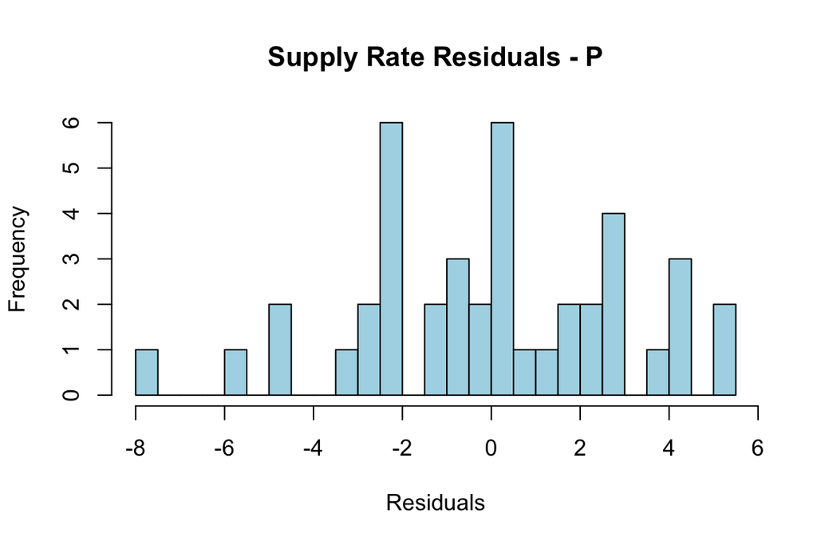

### 2.3.6 Quantile-Quantile plots

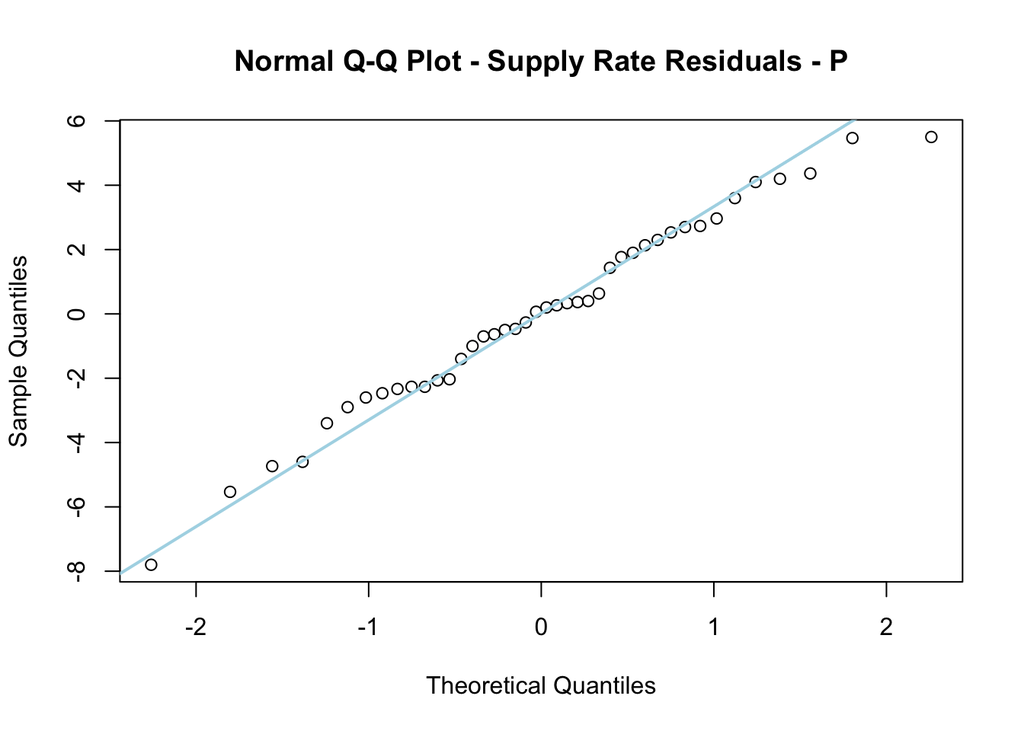

```r
qqnorm(anova_P$residuals, main = "Normal Q-Q Plot - Supply Rate Residuals - P")
qqline(anova_P$residuals, col = "lightblue", lwd = 2)
```

# 3 Discussion

## 3.1 Next steps

1. How do these data correlate with nutrient leachate (week 6)?
2. Consider nonparametric tests, or data normalization/relativization.